# Money Ball

## Problem 1D

Back in 2002, bases on balls (BB) did not receive as much attention as other statistics. Repeat the above analysis we performed for SB for BB per game. Do BB have larger effect on runs than SB?

```r
res_1D <- Teams %>% filter(yearID == 2002) %>%
  mutate(R_per_game = R / G, BB_per_game = BB / G) %>%
  lm(BB_per_game ~ R_per_game, data =.)

summary(res_1D)
```

```
##
## Call:
## lm(formula = BB_per_game ~ R_per_game, data = .)
##
## Residuals:
##      Min       1Q   Median       3Q      Max
## -0.75074 -0.27934  0.02897  0.28482  0.71039
##
## Coefficients:
##             Estimate Std. Error t value Pr(>|t|)
## (Intercept)   1.4978     0.6935   2.160   0.0395 *
## R_per_game    0.4007     0.1494   2.682   0.0121 *
## ---
## Signif. codes:  0 '***' 0.001 '**' 0.01 '*' 0.05 '.' 0.1 ' ' 1
##
## Residual standard error: 0.3842 on 28 degrees of freedom
## Multiple R-squared:  0.2044, Adjusted R-squared:  0.176
## F-statistic: 7.192 on 1 and 28 DF,  p-value: 0.01214
```

```r
tidy(res_1D, conf.int = TRUE)
```

```
##          term  estimate std.error statistic    p.value   conf.low
## 1 (Intercept) 1.4978094 0.6934920  2.159808 0.03949997 0.07725541
## 2  R_per_game 0.4006758 0.1494032  2.681842 0.01213990 0.09463721
##   conf.high
## 1 2.9183633
## 2 0.7067145
```

```r
## The CI (0.09, 0.71) shows a positive indicator of BB to Runs scored in a game, since zero is not in the interval
```

## Problem 1E

Association is not causation. It turns out that HR hitters also obtain many BB. We know for a fact that HRs cause runs because, by definition, they produce at least one. We can see this by simply plotting these two statistics for all players with more than 500 plate appearances (`BB+AB`):

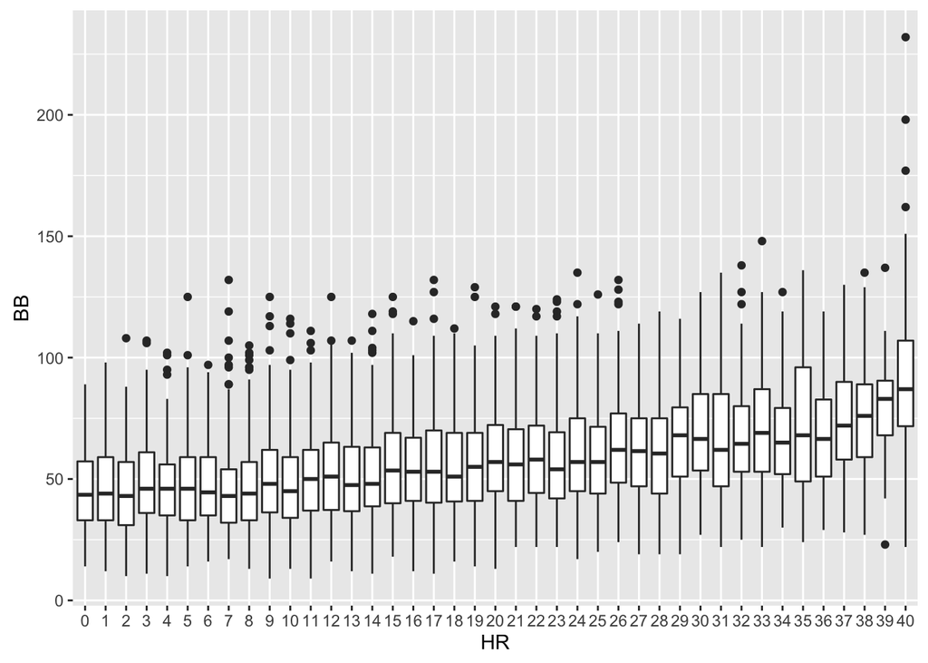

```r
Batting %>%
  filter(yearID >= 1961 & BB+AB > 500 & !is.na(HR) & !is.na(BB)) %>%
  mutate(HR = factor(pmin(HR, 40))) %>%
  ggplot(aes(HR, BB)) +
  geom_boxplot()
```

So is the relationship we saw above for BB and Runs due to teams having more HRs also having more BBs? One way we can explore this is by keeping HR fixed and examining the relationship within the strata. For example, if we only look only at teams with 150 home runs, do more BB produce more runs?

We can’t perform this analysis on a single year, because there are not enough teams to obtain strata with more than one or two teams. Instead we will combine all data years since 1961.

Group data by the number of HRs and perform a regression analysis in each stratum to determine the effect of BB per game on runs per game. Use 10th, 20th, … quantiles to split the data into 10 groups. Hint: use the function `cut` and `quantile` to create the strata.

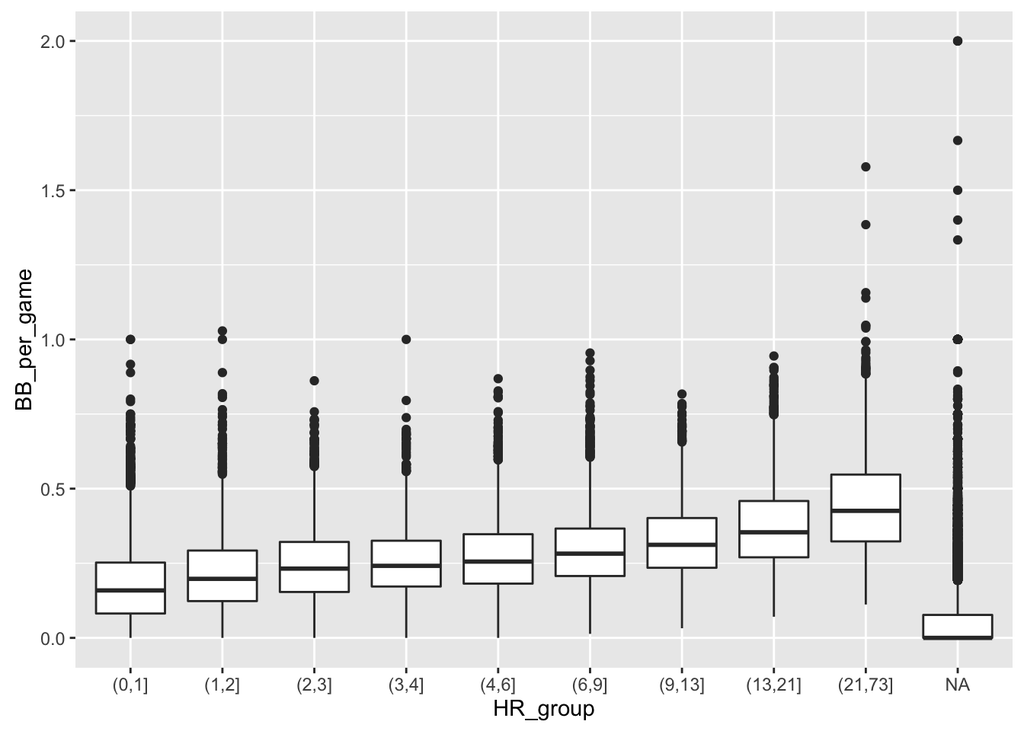

```r
## put your code here

plot_1E <- Batting %>% filter(yearID >= 1961) %>% mutate(HR_group = cut(HR, unique(quantile(HR, prob = seq(0,1,.05), na.rm = TRUE)),include.lowest=FALSE), BB_per_game = BB / G) %>%
  group_by(HR_group)

plot_1E %>%
  ggplot(aes(HR_group, BB_per_game)) +
    geom_boxplot()
```

## Problem 1F

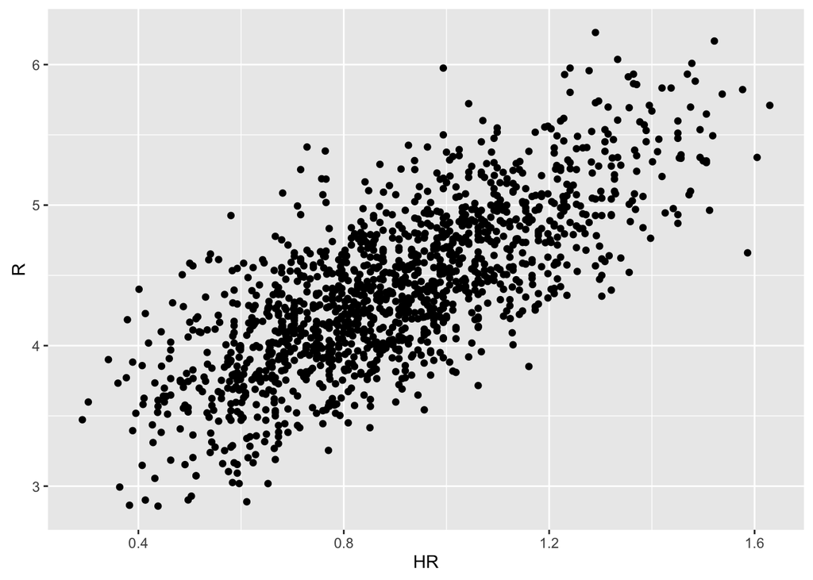

```r
Teams %>%
  filter(yearID >= 1961) %>%
  mutate(R = R / G, HR = HR / G) %>%
  ggplot(aes(HR, R)) +
  geom_point()
```

These two combined implies that a sensible linear model says:

$$\mbox{Runs} = \beta_0 + \beta_{BB} \mbox{BB} + \beta_{HR}{HR} + \varepsilon$$

In this model, we *adjust* for HRs by including it as linear term. Note that we have already showed data that support this model. In general, simply fitting such a model does not necessarily adjust for a possible confounded. The model must be approximately correct.

We can fit this model like this:

```r
fit <- Teams %>%
  filter(yearID >= 1961) %>%
  mutate(R = R / G, BB = BB / G, HR = HR / G) %>%
  lm(R ~ BB + HR, data = .)
summary(fit)
```

```
##
## Call:
## lm(formula = R ~ BB + HR, data = .)
##
## Residuals:
##      Min       1Q   Median       3Q      Max
## -0.94455 -0.23722 -0.01219  0.22386  1.25223
##
## Coefficients:
##             Estimate Std. Error t value Pr(>|t|)
## (Intercept)  1.74279    0.06963   25.03   <2e-16 ***
## BB           0.39985    0.02236   17.89   <2e-16 ***
## HR           1.50620    0.04006   37.60   <2e-16 ***
## ---
## Signif. codes:  0 '***' 0.001 '**' 0.01 '*' 0.05 '.' 0.1 ' ' 1
##
## Residual standard error: 0.3423 on 1413 degrees of freedom
## Multiple R-squared:  0.6421, Adjusted R-squared:  0.6416
## F-statistic:  1268 on 2 and 1413 DF,  p-value: < 2.2e-16
```

Note that the summary shows a very strong HR effect but also a decent BB effect. Now what happens if we include Singles (`H-X2B-X3B-HR`), Extra bases (doubles `X2B` and triples `X3B`), and HR per game. What does the model say about which of these characteristics should receive more weight. Fit the model to each year independently to check for consistency from year to year.

```r
## put your code here

fit_1F <- Teams %>%
  filter(yearID >= 1961) %>%
  mutate(R = R / G, BB = BB / G,
Singles = (H - X2B - X3B - HR) / G,
XB = (X2B + X3B) / G, HR = HR / G) %>%
  group_by(yearID) %>%
    do(mod = lm(R ~ BB + Singles + XB + HR, data = .))

#fit_1F$mod

fit_1F$yearID[1966]
```

```
## [1] NA
```

```r
summary(fit_1F$yearID[1966])
```

```
##    Min. 1st Qu.  Median    Mean 3rd Qu.    Max.    NA's
##      NA      NA      NA     NaN      NA      NA       1
```

```r
#summary(fit_1F$mod)

## I am not sure how to get a summarized result of the various Coefficients and p-values to determine which covariant is more valuable in this analysis
```

# Problem 2 (20% of grade)

In general, does spending money help a teams win? Here we will compute the payroll for each team each year. This information is not directly provided. But we have the salary for each player and we also what team they played each year.

Before we get started there is some data wrangling to be done.

```r
## We can use ifelse if you have not seen the revalue function
my_salaries <- Salaries %>%
  mutate(teamID = as.character(plyr::revalue(teamID, c(SFG = "SFN", NYM = "NYN"))))
```

## Problem 2A

Use the `mySalaries` data to compute each team’s payroll, in millions of dollars, for each team during each year. Save this into an object called `payroll`. Hints: Group by team and year and then sum all salaries. As a sanity check make a plot of payroll against year with color representing teams. Payroll should be increasing with the New York Yankees (code NYA) having the largest payroll. Consider plotting salaries in the log-scale.

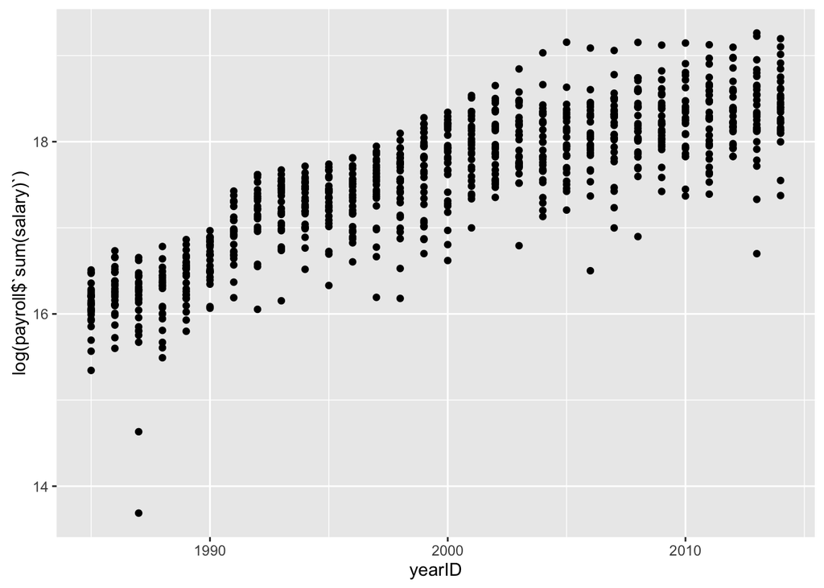

```r
library(ggplot2)
payroll <- my_salaries %>% group_by(teamID, yearID) %>% summarize(sum(salary))

 payroll %>% ggplot(aes(yearID, log(payroll$`sum(salary)`)), color = factor(payroll$teamID)) +
  geom_point() ## Sadly, could not get the colors to show correctly.
```

```r
#Credit for assistance: http://stackoverflow.com/questions/1660124/how-to-sum-a-variable-by-group
```

## Problem 2B

Now add the team’s winning percentage, wins / (wins + losses) for each year to the `payroll` table. Hints: The `Teams` table has wins and losses for each team for each year. The `dplyr` `join` functions permit you to join by two columns.

```r
payroll <- left_join(payroll, Teams[ , c("teamID", "yearID", "W","L")], by = c("teamID", "yearID"), all.x=T)
payroll <- payroll %>% mutate(win_percent = W / (W + L))
```